# S&P 500 Correlation Clustering

## Zak Taylor

1. Introduction
2. Installing Libraries
3. Scraping the Data
4. Correlating the Data
5. Clustering the Data
6. Putting it All Together
7. Results
8. Conclusion

## Introduction

In this project, we will be attempting to find groups of stocks in the S&P 500 that follow similar trends. This will be done by scraping time series data of S&P 500 stock prices from the last 5 years, correlating that data to find the relationships between each individual stock price, and finally, clustering that data into groups. The purpose of this project is to get more familiar with the concepts and algorithms used for clustering as well as clustering's capabilities to develop solutions to real world problems.

## Installing Libraries

The *time*, *datetime*, and *pandas* libraries will be used to scrape and format the data we are using

```python
import time
import datetime as dt
import pandas as pd
```

To visualize the data, we will use *matplotlib* and *seaborn*

```python
import matplotlib.pyplot as plt
import seaborn as sb
```

Finally, *scipy* and *numpy* will help to cluster and reorder the data

```python
import scipy
import scipy.cluster.hierarchy as sch
import numpy as np
```

## Scraping the Data

Before we begin to scrape the historical prices of every S&P 500 stock, we must first have a list of the symbols which will function as identifiers for these companies. This can be done simply by scraping [this](https://en.wikipedia.org/wiki/List_of_S%26P_500_companies) Wikipedia page that includes a table of information pertaining to every one of these securities.

```python
table=pd.read_html('https://en.wikipedia.org/wiki/List_of_S%26P_500_companies')
df = table[0]
tickers = df['Symbol']
tickers = tickers.to_list()
tickers = [s.replace('.', '-') for s in tickers]
tickers.remove("CEG")
```

Next, we will initialize variables to specify what data we want. In this instance, we are looking for weekly prices of every stock from January 1st, 2017 to January 1st, 2022

```python
interval = '1wk'
period1 = int(time.mktime(dt.datetime(2017, 1, 1).timetuple()))
period2 = int(time.mktime(dt.datetime(2022, 1, 1).timetuple()))
```

Before the data can be scraped, we need to set up the dataframe that the data will populate. This is done by creating a dataframe with one filled column as the date. A new column will later be appended to this dataframe for each company's data that we scrape.

```python
xlwriter = pd.ExcelWriter("historical prices.xlsx", engine = "openpyxl")
query_string = f'https://query1.finance.yahoo.com/v7/finance/download/AAPL?period1={period1}&period2={period2}&interval={interval}&events=history&includeAdjustedClose=true'
temp_df = pd.read_csv(query_string)
df = pd.DataFrame({"Date":temp_df["Date"]})
```

Now, we will finally scrape the data. This is done by using Yahoo Finance Queries that will return tables with a certain stock's price information including the open, high, low, and closing price. Since we are focusing on how the relationships between stocks over long periods of time, we only need to use the close prices. To save this data, we will take the column that contains the close prices and append it to the dataframe. This will be done for every stock in out list.

```python
for ticker in tickers:
    query_string = f'https://query1.finance.yahoo.com/v7/finance/download/{ticker}?period1={period1}&period2={period2}&interval={interval}&events=history&includeAdjustedClose=true'
    temp_df = pd.read_csv(query_string)
    temp_df2 = pd.DataFrame({ticker:temp_df["Close"]})
    df = pd.concat((df, temp_df2),axis = 1)
```

Finally, we will save this data to an excel file so that we can access it easily later on.

```python
df.to_excel(xlwriter, sheet_name=ticker, index=False)
xlwriter.save()
```

Here are the first 10 columns and rows of the dataframe to give an idea of what the data looks like

```python
df.iloc[:10, :10]
```

|  | Date | MMM | AOS | ABT | ABBV | ABMD | ACN | ATVI | ADM | ADBE |
| --- | --- | --- | --- | --- | --- | --- | --- | --- | --- | --- |
| 0 | 2017-01-01 | 178.229996 | 47.720001 | 40.779999 | 63.790001 | 115.419998 | 116.300003 | 37.910000 | 44.720001 | 108.300003 |
| 1 | 2017-01-08 | 177.389999 | 48.459999 | 40.930000 | 61.990002 | 115.669998 | 116.949997 | 38.950001 | 43.560001 | 108.529999 |
| 2 | 2017-01-15 | 178.490005 | 47.889999 | 40.459999 | 61.150002 | 111.839996 | 115.070000 | 38.970001 | 44.730000 | 110.709999 |
| 3 | 2017-01-22 | 177.479996 | 48.580002 | 41.000000 | 60.000000 | 108.849998 | 115.349998 | 39.610001 | 44.520000 | 113.989998 |
| 4 | 2017-01-29 | 175.039993 | 49.360001 | 42.779999 | 60.669998 | 104.959999 | 114.489998 | 40.009998 | 43.990002 | 115.169998 |
| 5 | 2017-02-05 | 179.000000 | 49.830002 | 42.740002 | 60.419998 | 108.639999 | 117.599998 | 47.230000 | 43.830002 | 116.849998 |
| 6 | 2017-02-12 | 182.949997 | 49.590000 | 44.689999 | 61.770000 | 116.570000 | 121.230003 | 45.330002 | 44.689999 | 119.669998 |
| 7 | 2017-02-19 | 187.410004 | 50.560001 | 45.680000 | 62.090000 | 117.139999 | 123.430000 | 45.549999 | 45.259998 | 119.309998 |
| 8 | 2017-02-26 | 189.309998 | 50.180000 | 45.250000 | 63.340000 | 120.730003 | 123.639999 | 47.070000 | 45.200001 | 120.040001 |
| 9 | 2017-03-05 | 191.210007 | 50.090000 | 45.720001 | 65.879997 | 121.209999 | 123.930000 | 49.200001 | 45.040001 | 121.089996 |

## Correlating the Data

Due to the sheer quantity of data we will be visualizing and analyzing, we will first be correlating and clustering the 30 securities used in the [Dow Jones Industrial Average](https://en.wikipedia.org/wiki/Dow_Jones_Industrial_Average). This is so we can view our data and how the code works more clearly before running it on a very large dataset. First, we will be running our previous code again but with the 30 Dow Jones stocks.

```python
query_string = f'https://query1.finance.yahoo.com/v7/finance/download/AAPL?period1={period1}&period2={period2}&interval={interval}&events=history&includeAdjustedClose=true'
table=pd.read_html('https://en.wikipedia.org/wiki/Dow_Jones_Industrial_Average')
df = table[1]
tickers = df['Symbol']
tickers = tickers.to_list()
tickers = [s.replace('.', '-') for s in tickers]

temp_df = pd.read_csv(query_string)
df = pd.DataFrame({"Date":temp_df["Date"]})

for ticker in tickers:
    query_string = f'https://query1.finance.yahoo.com/v7/finance/download/{ticker}?period1={period1}&period2={period2}&interval={interval}&events=history&includeAdjustedClose=true'
    temp_df = pd.read_csv(query_string)
    temp_df2 = pd.DataFrame({ticker:temp_df["Close"]})
    df = pd.concat((df, temp_df2),axis = 1)
```

To find relationships between stock prices, we must find the correlation between every pair of stocks in our dataframe. The graph below is a heatmap showing these correlations. Different correlation values inidicate different relationships between securites:

- Correlation values closer to 1.00 indicate that as one stock price increases, the other tends to increase as well.
- Correlation values closer to -1.00 indicate that as one stock price increases, the other tends to decrease
- Correlation values close to 0 indicate that there is little to no relationship between the two stock prices

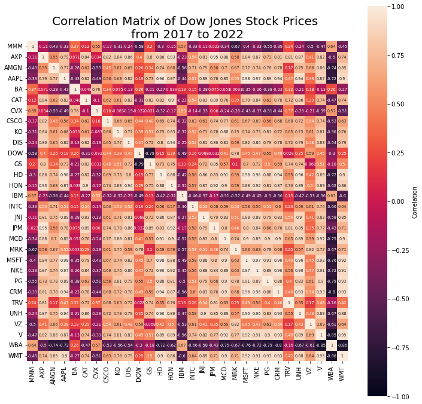

```python
corrMatrix = df.corr()
fig, ax = plt.subplots(figsize=(12, 12))
sb.heatmap(corrMatrix, annot = True, annot_kws={"fontsize":6.5},
           cbar_kws={'label': 'Correlation'}, square = True, vmin = -1, vmax =1)
plt.title('Correlation Matrix of Dow Jones Stock Prices \nfrom 2017 to 2022',
         fontsize = 20)
plt.show()
```

## Clustering the Data

To find groups of stocks that all have strong relationships between one another, we will use a process known as clustering. We will be using a hierarchical clustering algorithm that iteratively connects the closest data points to form groups, or clusters, of data.

```python
def cluster_corr(corr_array, inplace=False):

    pairwise_distances = sch.distance.pdist(corr_array)
    linkage = sch.linkage(pairwise_distances, method='complete')
    cluster_distance_threshold = pairwise_distances.max()/3.5
    idx_to_cluster_array = sch.fcluster(linkage, cluster_distance_threshold,
                                        criterion='distance')
    idx = np.argsort(idx_to_cluster_array)

    if not inplace:
        corr_array = corr_array.copy()

    if isinstance(corr_array, pd.DataFrame):
        return corr_array.iloc[idx, :].T.iloc[idx, :]
    return corr_array[idx, :][:, idx]
```

The data from the previous data has now been reordered so that the stocks with strong correlations to one another are close to one another. This data will again be visualized with a heat map.

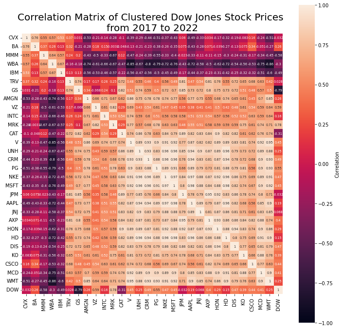

```python
fig, ax = plt.subplots(figsize=(12,12))
clustered_df = cluster_corr(df.corr())
sb.heatmap(clustered_df, annot = True, annot_kws={"fontsize":6.5},
           vmin = -1, vmax = 1, cbar_kws={'label': 'Correlation'}, square = True)
plt.title('Correlation Matrix of Clustered Dow Jones Stock Prices \nfrom 2017 to 2022',
         fontsize = 20)
plt.show()
```

With there being only 30 stocks in this instance, the clusters are not as prominent as they will be with the S&P 500. With that being said, we can still make out two prominent groups.

The first group is shown by the two dark purple rectangles on the heat map. From this cluster, we can see that the stocks on the axes from *CVX* to *IBM* have a mostly negative correlation with the stocks from *AMGN* to *DOW*. This means that generally as the stock prices from the first axis increase, the prices from the other axis decrease.

The second cluster visible is the large white/orange square. This shows that for the most part, all of the stocks from *V* to *WMT* are positively correlated which means that as the prices of all of the stocks tend to increase together.

## Putting it All Together

Now that we have see how clustering works on a smaller scale, we can apply it to our larger data set of all of the stocks from the S&P 500. First, we will plot the correlation matrix of the stocks before clustering them to show the initial ordering. The heat map below visualizes these correlations as colors on a gradient. Because each axis has over 500 values, we are not able to view which stock is which on this graph, however, the correlation values will also be stored in an excel file to be viewed individually.

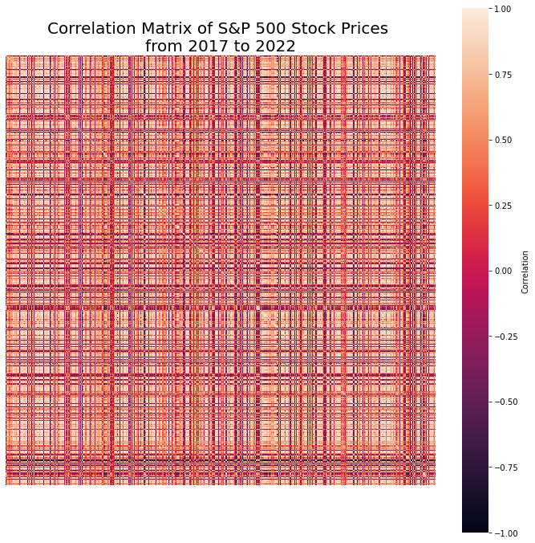

```python
df = pd.read_excel("historical prices.xlsx")
corrMatrix = df.corr()
fig, ax = plt.subplots(figsize=(12, 12))
sb.heatmap(corrMatrix, vmin = -1, vmax = 1,cbar_kws={'label': 'Correlation'}, square = True)
plt.axis('off')
plt.title('Correlation Matrix of S&P 500 Stock Prices \nfrom 2017 to 2022',
         fontsize = 20)
plt.show()
```

Now we will run the clustering algorithm again to produce groups of stocks with related trends.

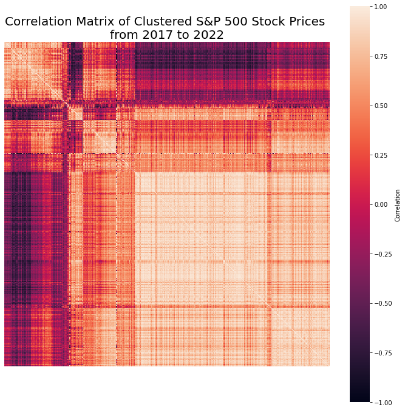

```python
fig, ax = plt.subplots(figsize=(12,12))
clustered_df = cluster_corr(df.corr())
sb.heatmap(clustered_df, vmin = -1, vmax = 1,cbar_kws={'label': 'Correlation'}, square = True)
plt.axis('off')
plt.title('Correlation Matrix of Clustered S&P 500 Stock Prices \nfrom 2017 to 2022',
         fontsize = 20)
plt.show()
```

The heat map produced shows us that there are multiple apparent clusters. To find what these groups are, we must perform a bit more code.

## Results

We will use some of the code we used previously to cluster the data except now we are doing it on the reordered matrix. This is because instead of reordering the rows and columns of the matrix, we will be assigning each stock a certain group number. Next, we will create a matrix similair to the clustered correlation matrix from earlier except the correlation values will be replaced with the group numbers.

```python
pairwise_distances = sch.distance.pdist(df.corr())
linkage = sch.linkage(pairwise_distances, method='complete')
ct = sch.cut_tree(linkage, 20)

groups = pd.DataFrame({"Group":ct[:,0], "Stock":df.columns[1:]})
groups_df = clustered_df

for column in groups_df:
    g1 = int(groups[groups['Stock']==column]['Group'])
    for row in groups_df:
        g2 = int(groups[groups['Stock']==row]['Group'])
        if g1==g2:
            groups_df[column][row] = g1
        else:
            groups_df[column][row] = -1
```

By visualizing the matrix as a heatmap, we can see a very similair graph to the one before except that every group now has its own distinct graph. This graph these 19 distinct groups and their sizes which allows us to see more clearly which stocks grow together.

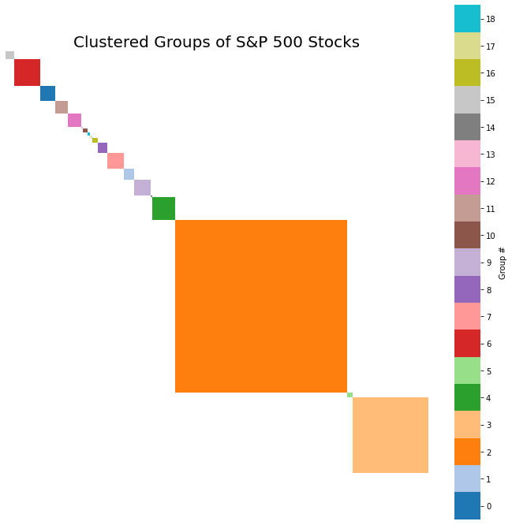

```python
cmap = sb.color_palette("tab20", 19)
fig, ax = plt.subplots(figsize=(12, 12))
sb.heatmap(groups_df, square = True, cmap = cmap, mask = groups_df < 0, vmin = 0,cbar_kws={'label': 'Group #'})
plt.axis('off')
plt.title('Clustered Groups of S&P 500 Stocks', fontsize = 20)

colorbar = ax.collections[0].colorbar
colorbar.set_ticks([x+0.5 for x in range(0,19)])
colorbar.set_ticklabels(range(0,19))

plt.show()
```

We can see an example of how our data can be used to make conclusions by selecting a group and seeing which stocks are in it. For simplicity's sake, we will choose a group that does not appear to have many stocks so we can view the stocks' growth more easily. We will use Group 1 as an example as it appears to be relatively small.

```python
groups[groups['Group']==1]
```

|  | Group | Stock |
| --- | --- | --- |
| 1 | 1 | AOS |
| 113 | 1 | CFG |
| 119 | 1 | CTSH |
| 126 | 1 | STZ |
| 163 | 1 | EMN |
| 187 | 1 | EXPE |
| 195 | 1 | FDX |
| 203 | 1 | F |
| 260 | 1 | IRM |
| 326 | 1 | MOS |
| 444 | 1 | TXT |
| 489 | 1 | WY |
| 500 | 1 | ZION |

As seen in the table, the stocks *AOS, CFG, CTSH, STZ, EMN, EXPE, FDX, F, IRM, MOS, TXT, WY,* and *ZION* all are in group 1 which means that as one of those stock prices increases, the otheres tend to increase as well. This can be see more clearly with a line graph.

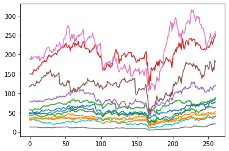

```python
for stock in groups[groups['Group']==1]['Stock']:
    plt.plot(df[stock])
plt.show()
```

The stocks all appear to follow very similair trends which shows how the stocks within each group also follow similar trends. This example of clustering shows just a fraction of the capabilities that clustering has. By clustering data into groups, we are then able to make predictions as to how the data will behave in the future which can lead to solving complex probelms in many different fields.